# Predict_Macro_Indicator

### Import libraries and a helper function to align data index between different data sources

```r
library(xts)
library(lubridate)
library(Quandl)
library(quantmod)
library(purrr)
library(tseries)
Quandl.api_key("M2-Rpsxfj4vXk5_22GAV")
fixDates <- function(dates) {
  yr <- format(dates, '%Y')
  mo <- format(dates, '%m')
  day <- '01'

  as.Date(paste0(yr, "-", mo, "-", day))
}
```

RESPONSE VARIABLE: Real GDP quarterly growth (annualized)

PREDICTOR VARIABLE 1: investor sentiment measured as spread between percentage of investors bullish and percentage of investors bearish, normalized by percent of investors that had a non-neutral view, i.e., were either bullish or bearish

PREDICTOR VARIABLE 2: consumer sentiment, as measured by University of Michigan surveys

### Download data for response variable

```r
GDP <- Quandl('FRED/A191RL1Q225SBEA') # quarterly series
GDP <- xts(GDP$Value, order.by = GDP$Date)
# make index correspond to quarter-ending month rather than quarter-beginning month
index(GDP) <- index(GDP) + months(2)
```

### Download data for predictor variables

```r
AAII <- Quandl('AAII/AAII_SENTIMENT') # weekly series
investor_sentiment_weekly <- na.trim(xts(AAII$`Bull-Bear Spread`/(1-AAII$Neutral), order.by=AAII$Date))
investor_sentiment_quarterly <- apply.quarterly(investor_sentiment_weekly, function(x){mean(x, na.rm=T)})
# to align with response, make index correspond to first day of quarter-ending month
index(investor_sentiment_quarterly) <- fixDates(index(investor_sentiment_quarterly))

MICH <- Quandl('UMICH/SOC1') # monthly series
consumer_sentiment <- xts(MICH$Index, order.by=MICH$Date)
consumer_sentiment_quarterly <- apply.quarterly(consumer_sentiment, function(x){mean(x, na.rm=T)})
index(consumer_sentiment_quarterly) <- fixDates(index(consumer_sentiment_quarterly))

data_gdp <- merge(merge(GDP, consumer_sentiment_quarterly, join = 'inner'),
                  investor_sentiment_quarterly, join = 'inner')
```

It is reasonable to expect that high investor and consumer sentiment today would be reflected in increased real gdp growth a quarter from now. We use lagged predictors for forecasting response.

```r
investor_sentiment_quarterold <- lag(investor_sentiment_quarterly)
consumer_sentiment_quarterold <- lag(consumer_sentiment_quarterly)

data_gdp <- na.trim(merge(merge(data_gdp, consumer_sentiment_quarterold, join='inner'),
                          investor_sentiment_quarterold, join='inner'))

mod <- lm(GDP ~ consumer_sentiment_quarterold + investor_sentiment_quarterold, data=data_gdp)
summary(mod)
```

```
##
## Call:
## lm(formula = GDP ~ consumer_sentiment_quarterold + investor_sentiment_quarterold,
##     data = data_gdp)
##
## Residuals:
##     Min      1Q  Median      3Q     Max
## -8.5189 -1.1928 -0.0477  1.4605  4.2393
##
## Coefficients:
##                               Estimate Std. Error t value Pr(>|t|)
## (Intercept)                   -3.27761    1.64134  -1.997  0.04814 *
## consumer_sentiment_quarterold  0.06313    0.01948   3.241  0.00155 **
## investor_sentiment_quarterold  2.69265    1.31305   2.051  0.04251 *
## ---
## Signif. codes:  0 '***' 0.001 '**' 0.01 '*' 0.05 '.' 0.1 ' ' 1
##
## Residual standard error: 2.179 on 118 degrees of freedom
## Multiple R-squared:  0.1943, Adjusted R-squared:  0.1807
## F-statistic: 14.23 on 2 and 118 DF,  p-value: 2.905e-06
```

### Residuals vs fitted values

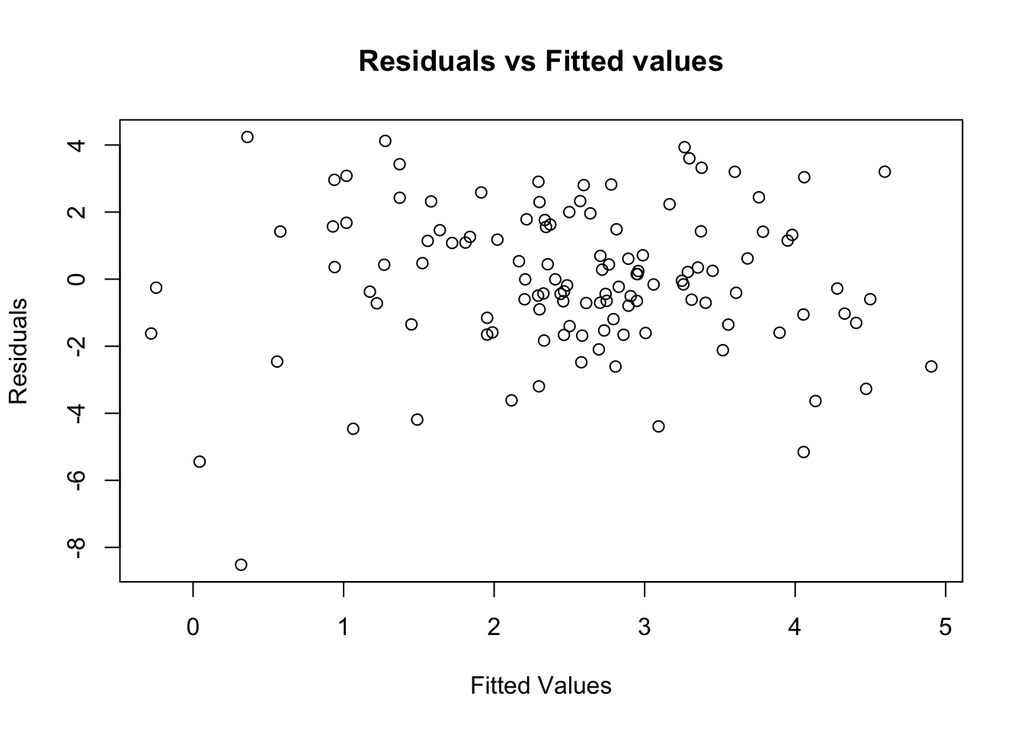

```r
plot(mod$fitted.values, mod$residuals, xlab="Fitted Values", ylab ="Residuals", main="Residuals vs Fitted values")
```

Residuals don’t look probelmatic. To be safe, check for stationarity of residuals using adf test.

```r
adf.test(mod$residuals, alternative="s")
```

```
##
##  Augmented Dickey-Fuller Test
##
## data:  mod$residuals
## Dickey-Fuller = -4.7737, Lag order = 4, p-value = 0.01
## alternative hypothesis: stationary
```

Strong evidence to reject the nonstationary null hypothesis.

### Response vs fitted values

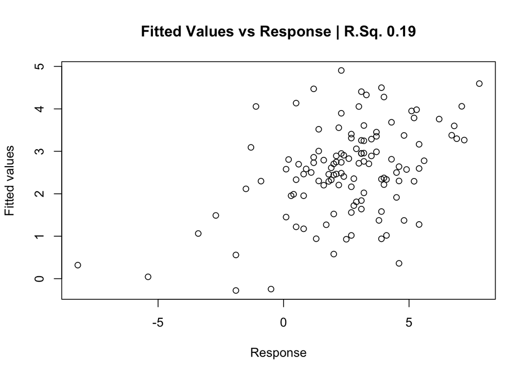

```r
plot(mod$fitted.values + mod$residuals, mod$fitted.values, xlab="Response", ylab="Fitted values",
     main=paste0("Fitted Values vs Response | R.Sq. ", round(summary(mod)$r.squared,2)))
```

### Final thoughts on pros and cons

1. The model achieved a decent R-Sq of 0.19 for a forecasting task, with the time series diagnostics also looking reasonable.
2. Given the low signal to noise ratio in economic series, a more sophisticated model might provide better in-sample performance, but would likely underperform out-of-sample.